# Team 12 - Assignment 04: Cluster Analysis, ANN and Text Mining Project

Using a [Python version 3.11.7](https://www.python.org/downloads/) globally or in a [virtual environment](https://realpython.com/python-virtual-environments-a-primer/)

1. Update pip: `python.exe -m pip install --upgrade pip`
2. run the following command in your terminal: `pip install -r requirements.txt`

This will install the required dependencies to run our Python code

- [ipykernel: the Python execution backend for Jupyter](https://pypi.org/project/ipykernel/)
- [matplotlib: a comprehensive library for creating static, animated, and interactive visualizations in Python](https://pypi.org/project/matplotlib/)
- [tensorflow: open source software library for high performance numerical computation.](https://pypi.org/project/tensorflow/)
  - As of 2023/12/08 `tensorflow` does not work with Python version 3.12.0
- [numpy: for scientific computing with Python](https://pypi.org/project/numpy/)
- [pandas: provides fast, flexible, and expressive data structures designed to make working with "relational" or "labeled" data both easy and intuitive](https://pypi.org/project/pandas/)
- [scikit-learn: for machine learning built on top of SciPy and is distributed under the 3-Clause BSD license](https://pypi.org/project/scikit-learn/)

**Team 12 Members**:

- [Alicia Luna](https://github.com/aluna4)
- [Derek Dilger](https://github.com/derekdilger)
- [Gary Young](https://github.com/garyyoungcsc)
- [Ian Schultz](https://github.com/Ian-Sanity)
- [Jesus Cervantes](https://github.com/Jescer3)
- [Matthew Mendoza](https://github.com/matt2ology)
- [Thomas Jaramillo-Ochoa](https://github.com/tjaramillo452329)
- [Yun-jeong Lee](https://github.com/yunjeongiya)

## 1. Clustering

### K-Means

Reading dataset to achieve K-means from cluster analysis

```python
import pandas as pd

# Load the dataset
imdb_data = pd.read_csv('./data/imdb_dataset.csv')

# Displaying the first few rows of the dataset for an overview
imdb_data.head()
```

|  | Unnamed: 0 | title | title_type | genre | runtime | mpaa_rating | studio | thtr_rel_year | thtr_rel_month | thtr_rel_day | ... | best_dir_win | top200_box | director | actor1 | actor2 | actor3 | actor4 | actor5 | imdb_url | rt_url |
| --- | --- | --- | --- | --- | --- | --- | --- | --- | --- | --- | --- | --- | --- | --- | --- | --- | --- | --- | --- | --- | --- |
| 0 | 1 | Filly Brown | Feature Film | Drama | 80.0 | R | Indomina Media Inc. | 2013 | 4 | 19 | ... | no | no | Michael D. Olmos | Gina Rodriguez | Jenni Rivera | Lou Diamond Phillips | Emilio Rivera | Joseph Julian Soria | http://www.imdb.com/title/tt1869425/ | //www.rottentomatoes.com/m/filly_brown_2012/ |
| 1 | 2 | The Dish | Feature Film | Drama | 101.0 | PG-13 | Warner Bros. Pictures | 2001 | 3 | 14 | ... | no | no | Rob Sitch | Sam Neill | Kevin Harrington | Patrick Warburton | Tom Long | Genevieve Mooy | http://www.imdb.com/title/tt0205873/ | //www.rottentomatoes.com/m/dish/ |
| 2 | 3 | Waiting for Guffman | Feature Film | Comedy | 84.0 | R | Sony Pictures Classics | 1996 | 8 | 21 | ... | no | no | Christopher Guest | Christopher Guest | Catherine O'Hara | Parker Posey | Eugene Levy | Bob Balaban | http://www.imdb.com/title/tt0118111/ | //www.rottentomatoes.com/m/waiting_for_guffman/ |
| 3 | 4 | The Age of Innocence | Feature Film | Drama | 139.0 | PG | Columbia Pictures | 1993 | 10 | 1 | ... | yes | no | Martin Scorsese | Daniel Day-Lewis | Michelle Pfeiffer | Winona Ryder | Richard E. Grant | Alec McCowen | http://www.imdb.com/title/tt0106226/ | //www.rottentomatoes.com/m/age_of_innocence/ |
| 4 | 5 | Malevolence | Feature Film | Horror | 90.0 | R | Anchor Bay Entertainment | 2004 | 9 | 10 | ... | no | no | Stevan Mena | Samantha Dark | R. Brandon Johnson | Brandon Johnson | Heather Magee | Richard Glover | http://www.imdb.com/title/tt0388230/ | //www.rottentomatoes.com/m/10004684-malevolence/ |

5 rows × 33 columns

Implementing the Elbow method by plotting SSE against possible cluster counts

```python
from sklearn.preprocessing import StandardScaler, OneHotEncoder
from sklearn.compose import ColumnTransformer
from sklearn.impute import SimpleImputer
from sklearn.pipeline import Pipeline
import numpy as np

# Selecting relevant features for clustering
# Assuming 'genre', 'runtime', 'mpaa_rating', 'imdb_rating', 'imdb_num_votes' as relevant features
features = ['genre', 'runtime', 'mpaa_rating', 'imdb_rating', 'imdb_num_votes']
imdb_data_selected = imdb_data[features]

# Preprocessing steps
# Handling missing values and encoding categorical data
# Numerical features will be standardized
numerical_features = imdb_data_selected.select_dtypes(
    include=['int64', 'float64']).columns
categorical_features = imdb_data_selected.select_dtypes(
    include=['object']).columns

numerical_pipeline = Pipeline([
    ('imputer', SimpleImputer(strategy='median')),
    ('std_scaler', StandardScaler())
])

categorical_pipeline = Pipeline([
    ('imputer', SimpleImputer(strategy='constant', fill_value='missing')),
    ('onehot', OneHotEncoder(handle_unknown='ignore'))
])

preprocessor = ColumnTransformer([
    ('num', numerical_pipeline, numerical_features),
    ('cat', categorical_pipeline, categorical_features)
])

# Preprocessing the data
imdb_data_preprocessed = preprocessor.fit_transform(imdb_data_selected)

# Checking the shape of the processed data
imdb_data_preprocessed.shape
```

```
(651, 20)
```

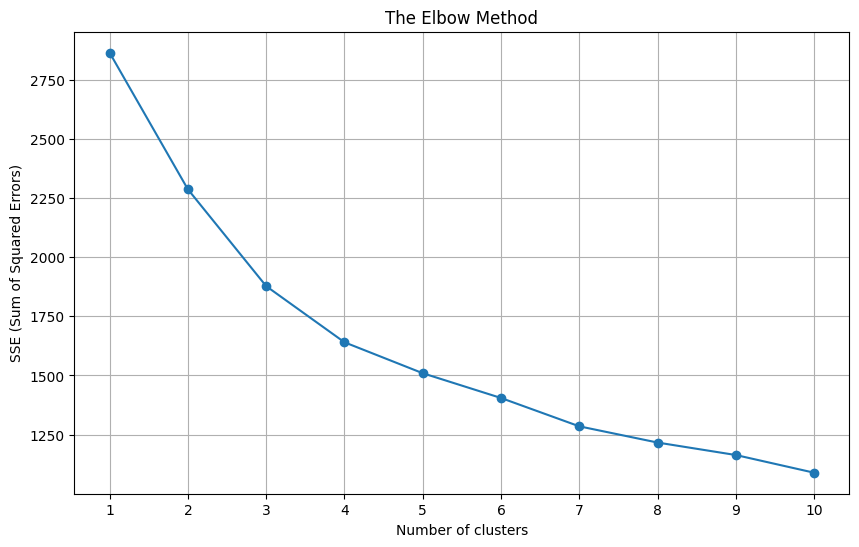

```python
from sklearn.cluster import KMeans
import matplotlib.pyplot as plt

# Determining the optimal number of clusters using the Elbow method
sse = []
range_clusters = range(1, 11)  # Trying with 1 to 10 clusters

for k in range_clusters:
    kmeans = KMeans(n_clusters=k, random_state=42)
    kmeans.fit(imdb_data_preprocessed)
    sse.append(kmeans.inertia_)

# Plotting the SSE vs number of clusters
plt.figure(figsize=(10, 6))
plt.plot(range_clusters, sse, marker='o')
plt.title('The Elbow Method')
plt.xlabel('Number of clusters')
plt.ylabel('SSE (Sum of Squared Errors)')
plt.xticks(range_clusters)
plt.grid(True)
plt.show()
```

Applying K-means clustering

```python
# Applying K-means clustering with the chosen number of clusters
optimal_clusters = 4
kmeans = KMeans(n_clusters=optimal_clusters, random_state=42)
kmeans.fit(imdb_data_preprocessed)

# Assigning the cluster labels to each movie
cluster_labels = kmeans.labels_

# Adding cluster labels to the original dataset for analysis
imdb_data['cluster'] = cluster_labels

# Displaying the first few rows with cluster labels
imdb_data[
    ['title',
     'genre',
     'runtime',
     'mpaa_rating',
     'imdb_rating',
     'imdb_num_votes',
     'cluster']
].head()
```

|  | title | genre | runtime | mpaa_rating | imdb_rating | imdb_num_votes | cluster |
| --- | --- | --- | --- | --- | --- | --- | --- |
| 0 | Filly Brown | Drama | 80.0 | R | 5.5 | 899 | 0 |
| 1 | The Dish | Drama | 101.0 | PG-13 | 7.3 | 12285 | 1 |
| 2 | Waiting for Guffman | Comedy | 84.0 | R | 7.6 | 22381 | 1 |
| 3 | The Age of Innocence | Drama | 139.0 | PG | 7.2 | 35096 | 2 |
| 4 | Malevolence | Horror | 90.0 | R | 5.1 | 2386 | 0 |

## Hierarchical

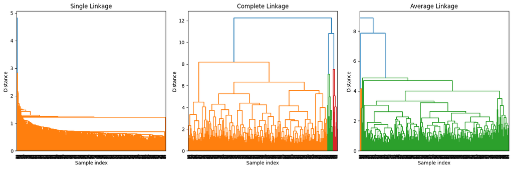

```python
import pandas as pd
from scipy.cluster.hierarchy import dendrogram, linkage
from sklearn.preprocessing import StandardScaler
import matplotlib.pyplot as plt
import numpy as np

# Load the dataset
data = pd.read_csv('./data/imdb_dataset.csv')

# Selecting relevant numerical features for clustering
features = data[["runtime", "thtr_rel_year", "imdb_rating",
                 "imdb_num_votes", "critics_score", "audience_score"]]

# Check for missing or infinite values and handle them
# Replace infinite values with NaN
features = features.replace([np.inf, -np.inf], np.nan)
features = features.dropna()  # Drop rows with NaN values

# Normalizing the data
scaler = StandardScaler()
features_scaled = scaler.fit_transform(features)

# Ensure the scaled data does not contain non-finite values
if not np.all(np.isfinite(features_scaled)):
    raise ValueError("Non-finite values found in scaled features")

# Hierarchical clustering with different linkages
linkage_methods = ['single', 'complete', 'average']
clusterings = {method: linkage(features_scaled, method=method)
               for method in linkage_methods}

# Plotting dendrograms for each linkage method
plt.figure(figsize=(15, 5))
for i, (method, clustering) in enumerate(clusterings.items(), 1):
    plt.subplot(1, 3, i)
    dendrogram(clustering)
    plt.title(f'{method.capitalize()} Linkage')
    plt.xlabel('Sample index')
    plt.ylabel('Distance')
plt.tight_layout()
plt.show()
```

## 2. Text Mining

```python
import sklearn.feature_extraction.text as sk_text

corpus = [
    'The sudden rainstorm washed crocodiles into the ocean.',
    'It turns out you dont need all that stuff you insisted you did.',
    'Tomatoes make great weapons when water balloons arent available.',
    'Ive traveled all around Africa and still havent found the gnu who stole my scarf.',
    'The group quickly understood that toxic waste was the most effective barrier to use against the zombies.',
    'Youve been eyeing me all day and waiting for your move like a lion stalking a gazelle in a savannah.',
]

vectorizer = sk_text.CountVectorizer(min_df=1)

matrix = vectorizer.fit_transform(corpus)

print(type(matrix))  # Compressed Sparse Row matrix
print(matrix.toarray())  # convert it to numpy array

print(vectorizer.get_feature_names_out())
```

```
<class 'scipy.sparse._csr.csr_matrix'>
[[0 0 0 0 0 0 0 0 0 0 1 0 0 0 0 0 0 0 0 0 0 0 0 0 0 1 0 0 0 0 0 0 0 0 0 0
  1 0 0 1 0 0 0 0 0 0 1 0 2 0 0 0 0 0 0 0 0 0 1 0 0 0 0 0 0 0 0 0]
 [0 0 1 0 0 0 0 0 0 0 0 0 1 1 0 0 0 0 0 0 0 0 0 0 1 0 1 0 0 0 0 0 0 0 0 1
  0 1 0 0 0 0 0 0 0 1 0 1 0 0 0 0 0 1 0 0 0 0 0 0 0 0 0 0 3 0 0 0]
 [0 0 0 0 1 0 1 1 0 0 0 0 0 0 0 0 0 0 0 0 1 0 0 0 0 0 0 0 0 0 1 0 0 0 0 0
  0 0 0 0 0 0 0 0 0 0 0 0 0 0 1 0 0 0 0 0 0 0 0 0 1 1 1 0 0 0 0 0]
 [1 0 1 1 0 1 0 0 0 0 0 0 0 0 0 0 0 1 0 1 0 0 1 0 0 0 0 1 0 0 0 0 0 0 1 0
  0 0 0 0 0 1 0 1 1 0 0 0 1 0 0 0 1 0 0 0 0 0 0 0 0 0 0 1 0 0 0 0]
 [0 1 0 0 0 0 0 0 1 0 0 0 0 0 1 0 0 0 0 0 0 1 0 0 0 0 0 0 0 0 0 0 1 0 0 0
  0 0 1 0 0 0 0 0 0 0 0 1 3 1 0 1 0 0 1 1 0 1 0 1 0 0 0 0 0 0 0 1]
 [0 0 1 1 0 0 0 0 0 1 0 1 0 0 0 1 1 0 1 0 0 0 0 1 0 0 0 0 1 1 0 1 0 1 0 0
  0 0 0 0 1 0 1 0 0 0 0 0 0 0 0 0 0 0 0 0 1 0 0 0 0 0 0 0 0 1 1 0]]
['africa' 'against' 'all' 'and' 'arent' 'around' 'available' 'balloons'
 'barrier' 'been' 'crocodiles' 'day' 'did' 'dont' 'effective' 'eyeing'
 'for' 'found' 'gazelle' 'gnu' 'great' 'group' 'havent' 'in' 'insisted'
 'into' 'it' 'ive' 'like' 'lion' 'make' 'me' 'most' 'move' 'my' 'need'
 'ocean' 'out' 'quickly' 'rainstorm' 'savannah' 'scarf' 'stalking' 'still'
 'stole' 'stuff' 'sudden' 'that' 'the' 'to' 'tomatoes' 'toxic' 'traveled'
 'turns' 'understood' 'use' 'waiting' 'was' 'washed' 'waste' 'water'
 'weapons' 'when' 'who' 'you' 'your' 'youve' 'zombies']
```

```python
vectorizer = sk_text.TfidfVectorizer(
    # stop_words='english',
    # max_features = 1000,
    min_df=1)


# max_features:build a vocabulary that only consider the top max_features features ordered by term frequency across the corpus.

matrix = vectorizer.fit_transform(corpus)

print(type(matrix))          # Compressed Sparse Row matrix
print(matrix.toarray())  # convert it to numpy array

print(vectorizer.get_feature_names_out())
```

```
<class 'scipy.sparse._csr.csr_matrix'>
[[0.         0.         0.         0.         0.         0.
  0.         0.         0.         0.         0.35539767 0.
  0.         0.         0.         0.         0.         0.
  0.         0.         0.         0.         0.         0.
  0.         0.35539767 0.         0.         0.         0.
  0.         0.         0.         0.         0.         0.
  0.35539767 0.         0.         0.35539767 0.         0.
  0.         0.         0.         0.         0.35539767 0.
  0.49209244 0.         0.         0.         0.         0.
  0.         0.         0.         0.         0.35539767 0.
  0.         0.         0.         0.         0.         0.
  0.         0.        ]
 [0.         0.         0.16249621 0.         0.         0.
  0.         0.         0.         0.         0.         0.
  0.23471514 0.23471514 0.         0.         0.         0.
  0.         0.         0.         0.         0.         0.
  0.23471514 0.         0.23471514 0.         0.         0.
  0.         0.         0.         0.         0.         0.23471514
  0.         0.23471514 0.         0.         0.         0.
  0.         0.         0.         0.23471514 0.         0.19246977
  0.         0.         0.         0.         0.         0.23471514
  0.         0.         0.         0.         0.         0.
  0.         0.         0.         0.         0.70414543 0.
  0.         0.        ]
 [0.         0.         0.         0.         0.33333333 0.
  0.33333333 0.33333333 0.         0.         0.         0.
  0.         0.         0.         0.         0.         0.
  0.         0.         0.33333333 0.         0.         0.
  0.         0.         0.         0.         0.         0.
  0.33333333 0.         0.         0.         0.         0.
  0.         0.         0.         0.         0.         0.
  0.         0.         0.         0.         0.         0.
  0.         0.         0.33333333 0.         0.         0.
  0.         0.         0.         0.         0.         0.
  0.33333333 0.33333333 0.33333333 0.         0.         0.
  0.         0.        ]
 [0.27085439 0.         0.18751586 0.22210447 0.         0.27085439
  0.         0.         0.         0.         0.         0.
  0.         0.         0.         0.         0.         0.27085439
```

[output cut: 26 more lines]

```
  0.         0.24882305 0.         0.24882305 0.         0.
  0.         0.         0.         0.         0.24882305 0.
  0.24882305 0.         0.         0.         0.         0.
  0.         0.         0.         0.         0.         0.
  0.         0.         0.24882305 0.         0.         0.
  0.         0.         0.         0.         0.         0.24882305
  0.24882305 0.        ]]
['africa' 'against' 'all' 'and' 'arent' 'around' 'available' 'balloons'
 'barrier' 'been' 'crocodiles' 'day' 'did' 'dont' 'effective' 'eyeing'
 'for' 'found' 'gazelle' 'gnu' 'great' 'group' 'havent' 'in' 'insisted'
 'into' 'it' 'ive' 'like' 'lion' 'make' 'me' 'most' 'move' 'my' 'need'
 'ocean' 'out' 'quickly' 'rainstorm' 'savannah' 'scarf' 'stalking' 'still'
 'stole' 'stuff' 'sudden' 'that' 'the' 'to' 'tomatoes' 'toxic' 'traveled'
 'turns' 'understood' 'use' 'waiting' 'was' 'washed' 'waste' 'water'
 'weapons' 'when' 'who' 'you' 'your' 'youve' 'zombies']
```

```python
# min_df: ignore terms that have a document frequency strictly lower than the given threshold.
vectorizer = sk_text.CountVectorizer(min_df=1)

matrix = vectorizer.fit_transform(corpus)

print(type(matrix))  # Compressed Sparse Row matrix
print(matrix.toarray())  # convert it to numpy array

print(vectorizer.get_feature_names_out())
```

```
<class 'scipy.sparse._csr.csr_matrix'>
[[0 0 0 0 0 0 0 0 0 0 1 0 0 0 0 0 0 0 0 0 0 0 0 0 0 1 0 0 0 0 0 0 0 0 0 0
  1 0 0 1 0 0 0 0 0 0 1 0 2 0 0 0 0 0 0 0 0 0 1 0 0 0 0 0 0 0 0 0]
 [0 0 1 0 0 0 0 0 0 0 0 0 1 1 0 0 0 0 0 0 0 0 0 0 1 0 1 0 0 0 0 0 0 0 0 1
  0 1 0 0 0 0 0 0 0 1 0 1 0 0 0 0 0 1 0 0 0 0 0 0 0 0 0 0 3 0 0 0]
 [0 0 0 0 1 0 1 1 0 0 0 0 0 0 0 0 0 0 0 0 1 0 0 0 0 0 0 0 0 0 1 0 0 0 0 0
  0 0 0 0 0 0 0 0 0 0 0 0 0 0 1 0 0 0 0 0 0 0 0 0 1 1 1 0 0 0 0 0]
 [1 0 1 1 0 1 0 0 0 0 0 0 0 0 0 0 0 1 0 1 0 0 1 0 0 0 0 1 0 0 0 0 0 0 1 0
  0 0 0 0 0 1 0 1 1 0 0 0 1 0 0 0 1 0 0 0 0 0 0 0 0 0 0 1 0 0 0 0]
 [0 1 0 0 0 0 0 0 1 0 0 0 0 0 1 0 0 0 0 0 0 1 0 0 0 0 0 0 0 0 0 0 1 0 0 0
  0 0 1 0 0 0 0 0 0 0 0 1 3 1 0 1 0 0 1 1 0 1 0 1 0 0 0 0 0 0 0 1]
 [0 0 1 1 0 0 0 0 0 1 0 1 0 0 0 1 1 0 1 0 0 0 0 1 0 0 0 0 1 1 0 1 0 1 0 0
  0 0 0 0 1 0 1 0 0 0 0 0 0 0 0 0 0 0 0 0 1 0 0 0 0 0 0 0 0 1 1 0]]
['africa' 'against' 'all' 'and' 'arent' 'around' 'available' 'balloons'
 'barrier' 'been' 'crocodiles' 'day' 'did' 'dont' 'effective' 'eyeing'
 'for' 'found' 'gazelle' 'gnu' 'great' 'group' 'havent' 'in' 'insisted'
 'into' 'it' 'ive' 'like' 'lion' 'make' 'me' 'most' 'move' 'my' 'need'
 'ocean' 'out' 'quickly' 'rainstorm' 'savannah' 'scarf' 'stalking' 'still'
 'stole' 'stuff' 'sudden' 'that' 'the' 'to' 'tomatoes' 'toxic' 'traveled'
 'turns' 'understood' 'use' 'waiting' 'was' 'washed' 'waste' 'water'
 'weapons' 'when' 'who' 'you' 'your' 'youve' 'zombies']
```

```python
vectorizer = sk_text.TfidfVectorizer(
    stop_words='english',  # remove stop words like 'the', 'a' etc.
    max_features=1000,  # only consider top 1000 words ordered by term frequency
    min_df=1  # ignore terms that have a document frequency < min_df.
)

matrix = vectorizer.fit_transform(corpus)

print(type(matrix))  # Compressed Sparse Row matrix
print(matrix.toarray())  # convert it to numpy array

print(vectorizer.get_feature_names_out())
```

```
<class 'scipy.sparse._csr.csr_matrix'>
[[0.         0.         0.         0.         0.         0.4472136
  0.         0.         0.         0.         0.         0.
  0.         0.         0.         0.         0.         0.
  0.         0.         0.         0.         0.4472136  0.
  0.4472136  0.         0.         0.         0.         0.
  0.4472136  0.         0.         0.         0.         0.
  0.         0.         0.4472136  0.         0.         0.
  0.         0.        ]
 [0.         0.         0.         0.         0.         0.
  0.         0.40824829 0.40824829 0.         0.         0.
  0.         0.         0.         0.         0.40824829 0.
  0.         0.         0.         0.40824829 0.         0.
  0.         0.         0.         0.         0.         0.40824829
  0.         0.         0.         0.         0.40824829 0.
  0.         0.         0.         0.         0.         0.
  0.         0.        ]
 [0.         0.35355339 0.35355339 0.35355339 0.         0.
  0.         0.         0.         0.         0.         0.
  0.         0.35355339 0.         0.         0.         0.
  0.         0.         0.35355339 0.         0.         0.
  0.         0.         0.         0.         0.         0.
  0.         0.35355339 0.         0.         0.         0.
  0.         0.         0.         0.         0.35355339 0.35355339
  0.         0.        ]
 [0.37796447 0.         0.         0.         0.         0.
  0.         0.         0.         0.         0.         0.
  0.37796447 0.         0.         0.37796447 0.         0.37796447
  0.         0.         0.         0.         0.         0.
  0.         0.         0.37796447 0.         0.37796447 0.
  0.         0.         0.         0.37796447 0.         0.
  0.         0.         0.         0.         0.         0.
  0.         0.        ]
 [0.         0.         0.         0.         0.33333333 0.
  0.         0.         0.         0.33333333 0.         0.
  0.         0.         0.33333333 0.         0.         0.
  0.         0.         0.         0.         0.         0.33333333
  0.         0.         0.         0.         0.         0.
  0.         0.         0.33333333 0.         0.         0.33333333
  0.33333333 0.         0.         0.33333333 0.         0.
  0.         0.33333333]
 [0.         0.         0.         0.         0.         0.
  0.33333333 0.         0.         0.         0.33333333 0.33333333
  0.         0.         0.         0.         0.         0.
  0.33333333 0.33333333 0.         0.         0.         0.
  0.         0.33333333 0.         0.33333333 0.         0.
  0.         0.         0.         0.         0.         0.
  0.         0.33333333 0.         0.         0.         0.
  0.33333333 0.        ]]
['africa' 'arent' 'available' 'balloons' 'barrier' 'crocodiles' 'day'
 'did' 'dont' 'effective' 'eyeing' 'gazelle' 'gnu' 'great' 'group'
 'havent' 'insisted' 'ive' 'like' 'lion' 'make' 'need' 'ocean' 'quickly'
 'rainstorm' 'savannah' 'scarf' 'stalking' 'stole' 'stuff' 'sudden'
 'tomatoes' 'toxic' 'traveled' 'turns' 'understood' 'use' 'waiting'
 'washed' 'waste' 'water' 'weapons' 'youve' 'zombies']
```

```python
vectorizer = sk_text.TfidfVectorizer(
    stop_words='english',  # remove stop words like 'the', 'a' etc.
    max_features=1000,  # only consider top 1000 words ordered by term frequency
    min_df=1,  # ignore terms that have a document frequency < min_df.
    max_df=0.5  # ignore terms that have a document frequency > max_df.
)

matrix = vectorizer.fit_transform(corpus)
print(type(matrix))  # Compressed Sparse Row matrix

tfidf_data = matrix.toarray()  # convert it to numpy array

print(tfidf_data)  # print the tfidf data
print(vectorizer.get_feature_names_out())  # get the feature names
```

```
<class 'scipy.sparse._csr.csr_matrix'>
[[0.         0.         0.         0.         0.         0.4472136
  0.         0.         0.         0.         0.         0.
  0.         0.         0.         0.         0.         0.
  0.         0.         0.         0.         0.4472136  0.
  0.4472136  0.         0.         0.         0.         0.
  0.4472136  0.         0.         0.         0.         0.
  0.         0.         0.4472136  0.         0.         0.
  0.         0.        ]
 [0.         0.         0.         0.         0.         0.
  0.         0.40824829 0.40824829 0.         0.         0.
  0.         0.         0.         0.         0.40824829 0.
  0.         0.         0.         0.40824829 0.         0.
  0.         0.         0.         0.         0.         0.40824829
  0.         0.         0.         0.         0.40824829 0.
  0.         0.         0.         0.         0.         0.
  0.         0.        ]
 [0.         0.35355339 0.35355339 0.35355339 0.         0.
  0.         0.         0.         0.         0.         0.
  0.         0.35355339 0.         0.         0.         0.
  0.         0.         0.35355339 0.         0.         0.
  0.         0.         0.         0.         0.         0.
  0.         0.35355339 0.         0.         0.         0.
  0.         0.         0.         0.         0.35355339 0.35355339
  0.         0.        ]
 [0.37796447 0.         0.         0.         0.         0.
  0.         0.         0.         0.         0.         0.
  0.37796447 0.         0.         0.37796447 0.         0.37796447
  0.         0.         0.         0.         0.         0.
  0.         0.         0.37796447 0.         0.37796447 0.
  0.         0.         0.         0.37796447 0.         0.
  0.         0.         0.         0.         0.         0.
  0.         0.        ]
 [0.         0.         0.         0.         0.33333333 0.
  0.         0.         0.         0.33333333 0.         0.
  0.         0.         0.33333333 0.         0.         0.
  0.         0.         0.         0.         0.         0.33333333
  0.         0.         0.         0.         0.         0.
  0.         0.         0.33333333 0.         0.         0.33333333
  0.33333333 0.         0.         0.33333333 0.         0.
  0.         0.33333333]
 [0.         0.         0.         0.         0.         0.
  0.33333333 0.         0.         0.         0.33333333 0.33333333
  0.         0.         0.         0.         0.         0.
  0.33333333 0.33333333 0.         0.         0.         0.
  0.         0.33333333 0.         0.33333333 0.         0.
  0.         0.         0.         0.         0.         0.
  0.         0.33333333 0.         0.         0.         0.
  0.33333333 0.        ]]
['africa' 'arent' 'available' 'balloons' 'barrier' 'crocodiles' 'day'
 'did' 'dont' 'effective' 'eyeing' 'gazelle' 'gnu' 'great' 'group'
 'havent' 'insisted' 'ive' 'like' 'lion' 'make' 'need' 'ocean' 'quickly'
 'rainstorm' 'savannah' 'scarf' 'stalking' 'stole' 'stuff' 'sudden'
 'tomatoes' 'toxic' 'traveled' 'turns' 'understood' 'use' 'waiting'
 'washed' 'waste' 'water' 'weapons' 'youve' 'zombies']
```

## 3. Artificial Neural Networks (ANN)

```python
from keras import Sequential
from keras.layers import Dense
from sklearn import preprocessing
from sklearn.metrics import accuracy_score, classification_report
import collections
import numpy as np
import pandas as pd

# Encode text values to dummy variables(i.e. [1,0,0],[0,1,0],[0,0,1] for red,green,blue)

def encode_text_dummy(df, name):
    dummies = pd.get_dummies(df[name])
    for x in dummies.columns:
        dummy_name = "{}-{}".format(name, x)
        df[dummy_name] = dummies[x]
    df.drop(name, axis=1, inplace=True)

# Encode text values to indexes(i.e. [1],[2],[3] for red,green,blue).

def encode_text_index(df, name):
    le = preprocessing.LabelEncoder()
    df[name] = le.fit_transform(df[name])
    return le.classes_

# Convert a Pandas dataframe to the x,y inputs that TensorFlow needs

def to_xy(df, target):
    result = []
    for x in df.columns:
        if x != target:
            result.append(x)
    # find out the type of the target column.
    target_type = df[target].dtypes
    target_type = target_type[0] if isinstance(
        target_type, collections.abc.Sequence) else target_type
    # Encode to int for classification, float otherwise. TensorFlow likes 32 bits.
    if target_type in (np.int64, np.int32):
        # Classification
        dummies = pd.get_dummies(df[target])
        return df[result].values.astype(np.float32), dummies.values.astype(np.float32)
    else:
        # Regression
        return df[result].values.astype(np.float32), df[target].values.astype(np.float32)
```

[output not shown]

```python
# Loading the dataset
data_df = pd.read_csv('data/admission_data_set.csv', header='infer')
```

```python
# Dropping unnecessary Columns
data_df = data_df.drop('SOP', axis=1)
data_df = data_df.drop('LOR', axis=1)
data_df = data_df.drop('CGPA', axis=1)
data_df
```

|  | Serial No. | GRE Score | TOEFL Score | University Rating | Research | Chance of Admit |
| --- | --- | --- | --- | --- | --- | --- |
| 0 | 1 | 337 | 118 | 4 | 1 | 0.92 |
| 1 | 2 | 324 | 107 | 4 | 1 | 0.76 |
| 2 | 3 | 316 | 104 | 3 | 1 | 0.72 |
| 3 | 4 | 322 | 110 | 3 | 1 | 0.80 |
| 4 | 5 | 314 | 103 | 2 | 0 | 0.65 |
| ... | ... | ... | ... | ... | ... | ... |
| 495 | 496 | 332 | 108 | 5 | 1 | 0.87 |
| 496 | 497 | 337 | 117 | 5 | 1 | 0.96 |
| 497 | 498 | 330 | 120 | 5 | 1 | 0.93 |
| 498 | 499 | 312 | 103 | 4 | 0 | 0.73 |
| 499 | 500 | 327 | 113 | 4 | 0 | 0.84 |

500 rows × 6 columns

```python
# Loading the test data
testdata = data_df[0:100]
testdata
```

|  | Serial No. | GRE Score | TOEFL Score | University Rating | Research | Chance of Admit |
| --- | --- | --- | --- | --- | --- | --- |
| 0 | 1 | 337 | 118 | 4 | 1 | 0.92 |
| 1 | 2 | 324 | 107 | 4 | 1 | 0.76 |
| 2 | 3 | 316 | 104 | 3 | 1 | 0.72 |
| 3 | 4 | 322 | 110 | 3 | 1 | 0.80 |
| 4 | 5 | 314 | 103 | 2 | 0 | 0.65 |
| ... | ... | ... | ... | ... | ... | ... |
| 95 | 96 | 304 | 100 | 4 | 0 | 0.42 |
| 96 | 97 | 306 | 100 | 2 | 0 | 0.48 |
| 97 | 98 | 331 | 120 | 3 | 1 | 0.86 |
| 98 | 99 | 332 | 119 | 4 | 1 | 0.90 |
| 99 | 100 | 323 | 113 | 3 | 1 | 0.79 |

100 rows × 6 columns

```python
# Encoding the data based on the Research Column
encode_text_index(testdata, 'Research')
```

```
array([0, 1], dtype=int64)
```

```python
# Splitting the data by the Research Column
X, Y = to_xy(data_df, 'Research')
testX, testY = to_xy(data_df, 'Research')
```

```python
# Generating the ANN model
model = Sequential()
model.add(Dense(12, input_dim=X.shape[1], activation='relu'))
model.add(Dense(6, activation='relu'))
model.add(Dense(2, activation='softmax'))
model.compile(loss='categorical_crossentropy', optimizer='adam')
model.fit(X, Y, verbose=2, epochs=100)
```

[output not shown]

[output cut: 51 more lines]

```
16/16 - 0s - loss: 0.6932 - 17ms/epoch - 1ms/step
16/16 - 0s - loss: 0.6901 - 16ms/epoch - 1ms/step
16/16 - 0s - loss: 0.6912 - 15ms/epoch - 907us/step
16/16 - 0s - loss: 0.7079 - 17ms/epoch - 1ms/step
16/16 - 0s - loss: 0.7098 - 15ms/epoch - 937us/step
16/16 - 0s - loss: 0.7041 - 14ms/epoch - 875us/step
16/16 - 0s - loss: 0.6933 - 14ms/epoch - 875us/step
16/16 - 0s - loss: 0.6931 - 15ms/epoch - 938us/step
16/16 - 0s - loss: 0.6905 - 16ms/epoch - 970us/step
16/16 - 0s - loss: 0.6950 - 15ms/epoch - 937us/step
16/16 - 0s - loss: 0.6906 - 16ms/epoch - 1000us/step
16/16 - 0s - loss: 0.7084 - 15ms/epoch - 938us/step
16/16 - 0s - loss: 0.7022 - 15ms/epoch - 938us/step
16/16 - 0s - loss: 0.6965 - 16ms/epoch - 1ms/step
16/16 - 0s - loss: 0.6970 - 15ms/epoch - 938us/step
```

```
<keras.src.callbacks.History at 0x1f11508f790>
```

```python
pred = model.predict(testX)
print(pred[0])
```

```
[0.36167884 0.6383211 ]
```

```python
pred = np.argmax(pred, axis=1)
true = np.argmax(testY, axis=1)
print('Accuracy on test data is %.2f' % (accuracy_score(true, pred)))
```

```
Accuracy on test data is 0.59
```

```python
print(classification_report(true, pred))
```

```
              precision    recall  f1-score   support

           0       0.65      0.14      0.23       220
           1       0.58      0.94      0.72       280

    accuracy                           0.59       500
   macro avg       0.62      0.54      0.47       500
weighted avg       0.61      0.59      0.50       500
```